# Simulation Study **Vol. 3**

## Verification

Implemented the script as was asked of me. To simplyfy the code I decided to write a short class that saves all the measurements in a single object. The plot and printout result in: (orange in the middle!)

```python
from part3_simstudy import *
from matplotlib import pyplot as pp
```

```
Real Mean: 0.2, empirical mean 0.19915573134134146, difference=0.0008442686586585535
```

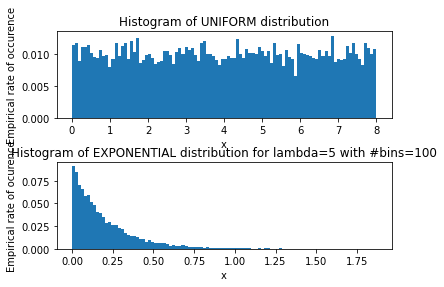

```python
task_3_2_1()
```

```
For SIM_TIME=100 the mean utilization was [0.009654840000000003, 0.4971434499999996, 0.7394273400000005, 0.8014706899999995]
For SIM_TIME=1000 the mean utilization was [0.00953046699999999, 0.49609676699999955, 0.7446542700000001, 0.8069728339999994]
```

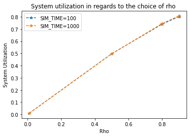

```python
task_3_2_2()
```

# Analysis and General Questions

## 3.3.1 System with different Queue capacity

To understand this we first have to understand how the radom number generators work. When given the same seed twice and genearte a random sequence using a random number generator such as the one in the lib random, we see that the two sequences are exatly the same! Not so random after ha - this makes sense since we can better understand how a change in the system design affects performance, otherwise we could never be certain if it was just by acciedent that the system performed differently (or not). THus the results of simulations are deterministic and can be compared.

```python
import random as r

def get_random_seq(a):
  rl = []
  for i in range(a):
    rl.append(r.uniform(0,1))
  return rl

r.seed(47)
r1 = get_random_seq(5)
r.seed(47)
r2 = get_random_seq(5)
print(r1, "\n", r2)
```

```
[0.35184625582788265, 0.430186245990098, 0.4536708635895742, 0.3434697408782532, 0.5124443649244089]
 [0.35184625582788265, 0.430186245990098, 0.4536708635895742, 0.3434697408782532, 0.5124443649244089]
```

## 3.3.2 Choosing the right number of bins

I use n=10k realization of my 2 distribtuions for the plots above. I decided to use the rule of thumb that says to use sqrt(n) to plot the histograms. As we can see, this seems to be a good match since we can quite clearly figure out that the underlying distribution is a exponential or unifrom one. If we raise the number of bins to 1k, the histograms become much peakier. If we lower the amout to just 10 the histograms beocme flatter. We can still from both figure out what the underlying distribtuion is but also notice that the number of bins is either too high or too low (check the empirical rate).

Thus the rule of thumb seems to be a very good pick for these plots.

```
Real Mean: 0.2, empirical mean 0.20180409568257823, difference=0.0018040956825782217
```

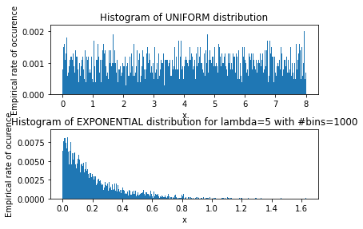

```
Real Mean: 0.2, empirical mean 0.1992160906154974, difference=0.0007839093845026235
```

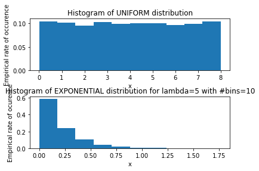

```python
task_3_2_1(bins=1000)
task_3_2_1(bins=10)
```

## 6.6.6/2.2.2 = 3.3.3 System utilization

Increasing the simulation time to 1000s slightly increases the utilization, I think this trend continues and for a infinite simulation time we would reach the rho.

Increasing the buffer size to inf would eliminate packet loss, thus the utiliation should be closer to rho. This is true, see figure below.

```
For SIM_TIME=100 the mean utilization was [0.009654840000000003, 0.4971434499999996, 0.7394273400000005, 0.8014706899999995]
For SIM_TIME=100 the mean utilization was [0.009609420000000002, 0.49839586, 0.7803678000000006, 0.8517035799999992]
For SIM_TIME=100 the mean utilization was [0.009666419999999993, 0.49919852000000037, 0.7708630799999999, 0.8551933099999999]
```

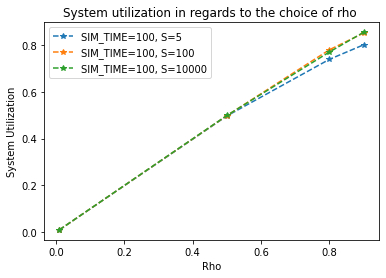

```python
task_3_2_2_2()
```